# Data science eliminatory test

Davi Stern

```r
library(readxl)
library(here)
library(tidyverse)
```

–> Dados de venda - df_sales - ID: identificador único de uma venda - ProductID: identificador único de um produto - ClientID: identificador único de um cliente - Discount: desconto aplicado em uma venda - UnitPrice: preço unitário de um produto vendido - Quantity: quantidade de produto vendido em uma venda - StoreID: identificador único de uma loja - Date: data de uma venda

–> Dados de consumidores - df_costumers - ID: identificador único de um consumidor - City: cidade/localidade onde um consumidor fez a compra - State: Unidade Federativa onde um consumidor fez a compra - DateOfBirth: data de nascimento de um consumidor - Sex: sexo de um consumidor

–> Dados de lojas - df_store - ID: identificador único de uma loja - Name: cidade/localidade de uma loja - State: Unidade Federativa de uma loja

–> Dados de produto - df_products - ID: identificador único de um produto - Name: nome de um produto - Size: tamanho de um produto

```r
sheet_path <- "data/Base de Dados - Questionário.xlsx"

df_sales <- read_xlsx(sheet_path, sheet = "Sheet1")

df_customers <- read_xlsx(sheet_path, sheet = "Sheet3")

df_store <- read_xlsx(sheet_path, sheet = "Sheet4")

df_products <- read_xlsx(sheet_path, sheet = "Sheet2")
```

```r
df_join <- df_sales %>%
    left_join(
        df_products, by = c("ProductID" = "ID")
        ) %>%
    left_join(
        df_customers, by = c("ClientID" = "ID")
    ) %>%
    left_join(
        df_store, by = c("StoreID" = "ID"), suffix = c(".join", ".store")
    )
```

```r
df_unique_sales <-
    df_sales %>%
    group_by(ProductID) %>%
    summarise(count = n()) %>%
    arrange(desc(count)) %>%
    left_join(df_products, by = c("ProductID" = "ID"))
```

```r
Answer_5 <- glue::glue("Foram vendidos {nrow(df_unique_sales)} produtos únicos") %>%
    print()
```

```
## Foram vendidos 73 produtos únicos
```

```r
df_total_sales <-
    df_sales %>%
    group_by(ProductID) %>%
    summarise(total_vendas = sum(Quantity)) %>%
    arrange(desc(total_vendas)) %>%
    left_join(df_products, by = c("ProductID" = "ID"))

df_total_sales
```

```
## # A tibble: 73 x 4
##    ProductID                         total_vendas Name           Size
##    <chr>                                    <dbl> <chr>          <chr>
##  1 002ec297b1b00fb9dde7ee6ac24b67713         1020 Bazinga        G
##  2 002d4ea7c04739c130bb74d7e7cd16943         1018 Iron Man       G
##  3 0009406fd7479715e4bef61dd91f24623          998 Deadpool       G
##  4 0011c512eb256aa0dbbb544d8dffcf6e3          996 Flash          G
##  5 001c5d71ac6ad696d22315953758fa043          996 Capitã Marvel  G
##  6 0030026a6ddb3b2d1d4bc225b4b4c4da3          992 League Legends G
##  7 001b237c0e9bb435f2e54071129237e93          990 Thanos         G
##  8 00126f27c813603687e6ce486d909d013          987 Coringa        G
##  9 002c6dab60557c48cfd6c2222ef7fd763          985 Darth Vader    G
## 10 002af88741ba70c7b5cf4e4a0ad7ef853          975 Dragon Ball Z  G
## # ... with 63 more rows
```

```r
Answer_6 <- glue::glue("O produto mais vendido foi {df_total_sales$Name[1]}, tamanho {df_total_sales$Size[1]} com {df_total_sales$total_vendas[1]} unidades vendidas") %>%
    print()
```

```
## O produto mais vendido foi Bazinga, tamanho G com 1020 unidades vendidas
```

7. Considerando o ano de 2019, qual gráfico abaixo mais se parece à quantidade mensal do vendida do produto “Iron Man, G” ?

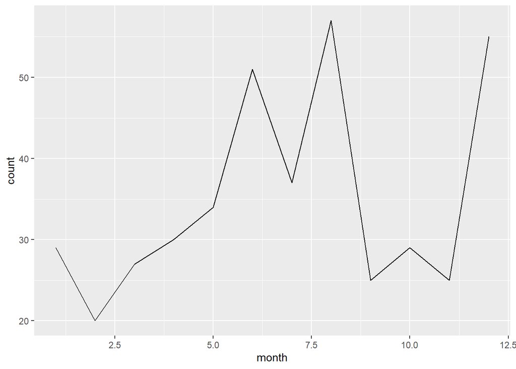

```r
df_prod_filtered <- df_products %>%
    filter(Name == "Iron Man" & Size == "G")


df_sales_2019 <-  df_sales %>%
    filter(lubridate::year(Date) == 2019) %>%
    right_join(df_prod_filtered, by = c("ProductID" = "ID")) %>%
    group_by(month = lubridate::month(Date)) %>%
    summarise(count = n())


plot_sales_2019 <- df_sales_2019 %>%
    ggplot(aes(month, count)) +
    geom_line()

plot_sales_2019
```

8. Considerando a *receita líquida* *mensal* de vendas em *2019*. Quais os valores de: média, mediana e desvio padrão desses valores?
9. agregar valor de venda por mês
10. calcular receita total considerando o desconto

```r
montly_sales_2019_complete <- df_sales %>%
    filter(lubridate::year(Date) == 2019) %>%
    mutate(Month = lubridate::month(Date)) %>%
    group_by(Month) %>%
    summarise(receita_liquida = sum((UnitPrice * (1 - Discount)) * Quantity))
```

```r
mean <- mean(montly_sales_2019_complete$receita_liquida)

median <- median(montly_sales_2019_complete$receita_liquida)

sd <- sd(montly_sales_2019_complete$receita_liquida)
```

```r
answer_8 <- glue::glue("{mean} // {median} // {sd}")

print(answer_8)
```

```
## 294265.094666667 // 257390.91 // 99304.561130443
```

9. Ainda considerando os dados de receita líquida de vendas em 2019, seu time deve focar esforços em uma das lojas para criar análises mais profundas e a primeira versão do modelo preditivo. Qual destas lojas você escolheria para prosseguir com o projeto? (1 ponto)

Quais criterios?

considerando que preciso fittar um modelo, eu preciso utilizar a loja com maior numero de observações para permitir a divisao entre testes, validaçoes e treinos

portanto podemos começar selecionando a loja com maior numero de vendas em 2019

```r
sales_2019_by_store <- df_sales %>%
    filter(lubridate::year(Date) == 2019) %>%
    mutate(
        Month = lubridate::month(Date),
        receita_liquida = ((UnitPrice * (1 - Discount)) * Quantity)
        ) %>%
    left_join(df_store, by = c("StoreID" = "ID"))


sales_per_store <- sales_2019_by_store %>%
    group_by(Name, Month) %>%
    summarise(receita_liq = sum(receita_liquida),
              count = n()
              )
```

Receita se comporta de maneira similar entre Florianópolis, Rio, Porto Alegre, de maneira geral, há claras tendencias sazonais nas vendas

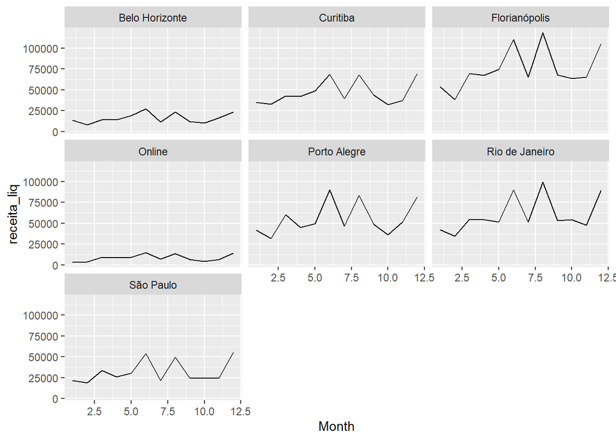

```r
receita_plot <- sales_per_store %>% ggplot(aes(Month, receita_liq))+
    geom_line()+
    facet_wrap(~Name)


receita_plot
```

O comportamento da quantidade vendida é similar a da receita

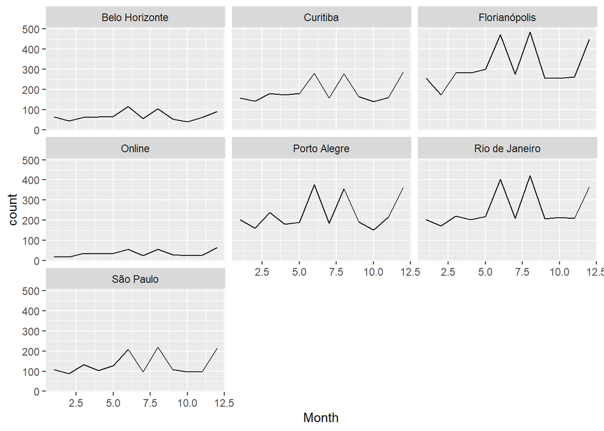

```r
count_plot <- sales_per_store %>% ggplot(aes(Month, count))+
    geom_line()+
    facet_wrap(~Name)


count_plot
```

Florianópolis tem o maior sample size, mas seria importante analisar o perfil dos clientes entre as lojas

```r
sales_per_store_anual <- sales_2019_by_store %>%
    group_by(Name) %>%
    summarise(receita_liq = sum(receita_liquida),
              count = n()
              )
sales_per_store_anual %>% arrange(desc(receita_liq))
```

```
## # A tibble: 7 x 3
##   Name           receita_liq count
##   <chr>                <dbl> <int>
## 1 Florianópolis      900117.  3750
## 2 Rio de Janeiro     723402.  3048
## 3 Porto Alegre       668056.  2814
## 4 Curitiba           560306.  2304
## 5 São Paulo          384676.  1602
## 6 Belo Horizonte     192495.   823
## 7 Online             102131.   427
```

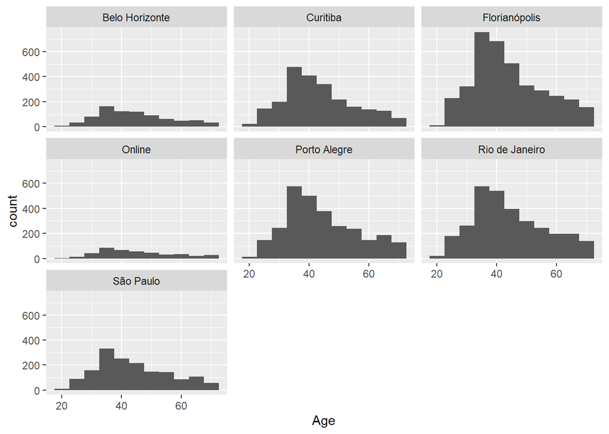

```r
sales_per_store_clients <- sales_2019_by_store %>%
    left_join(df_customers, by = c("ClientID" = "ID")) %>%
    select(-State.x, -State.y) %>%
    mutate(Age = lubridate::year(lubridate::today()) - lubridate::year(DateOfBirth))

count_per_age <-
    sales_per_store_clients %>%
    group_by(Name, Age)

count_per_age_plot <-
    count_per_age %>% ggplot(aes(Age))+
    geom_histogram(binwidth = 5)+
    facet_wrap(~Name)


count_per_age_plot
```

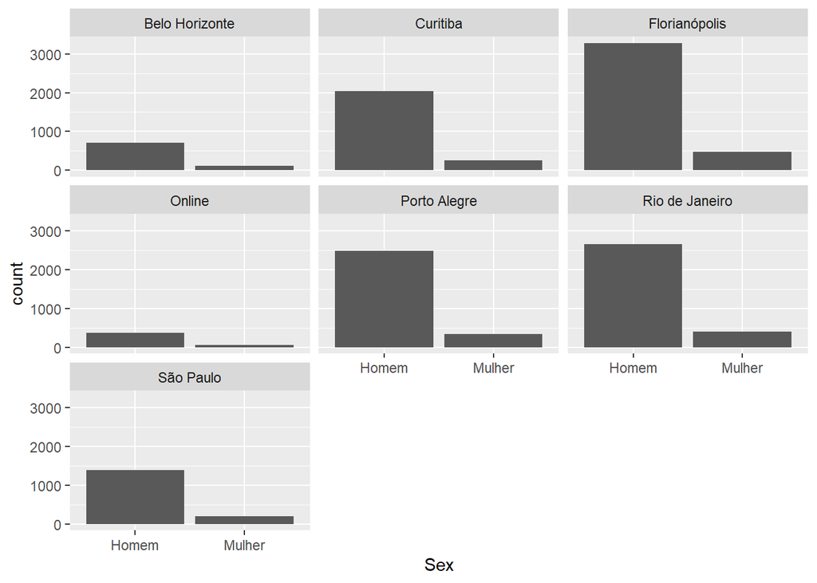

```r
count_per_sex <-
    sales_per_store_clients %>%
    group_by(Name, Sex)

count_per_sex_plot <-
    count_per_sex %>% ggplot(aes(Sex))+
    geom_histogram(stat = "count")+
    facet_wrap(~Name)
count_per_sex_plot
```